# Part II - Factors contributing to rides taken at Ford GoBike System

## by Vanessa Arhin

## Investigation Overview

> My focus for the presentation is on what are the peak days and hours for the bike sharing system. I will introduce the day variable(for start time), followed by the hours in day, then plot the relationship between these two variables using a heat map.

> Also, I will introduce user type variable as a single variable. Then I will compare user type with ride duration and also days in the week to determine what user uses the bike system the most.

## Dataset Overview

> This dataset includes information about individual rides made in a bike-sharing system covering the greater San Francisco Bay area.

## Distribution of Trip Start Day

Trips taken at bike stations are spread across various days of the week. The lowest number of rides are taken on weekends which is about 15,000 rides and most trips are taken during weekdays with the highest number of rides at about 35,000.

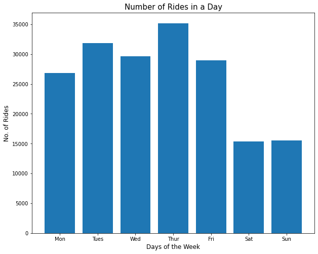

```python
labels = ['Mon', 'Tues', 'Wed', 'Thur', 'Fri', 'Sat', 'Sun']

plt.figure(figsize=(10,8))
plt.bar(labels, start_time_day)
plt.title('Number of Rides in a Day', size = 15)
plt.xlabel('Days of the Week', size = 12)
plt.ylabel('No. of Rides', size = 12);
```

## Distribution of Trip Start Hour

Hourly count of bike rides helps determine what the peak hours are in a day. The peak hours are **7am - 9am** and **4pm - 6pm** with the highest count of more than 40,000 in the mornings.

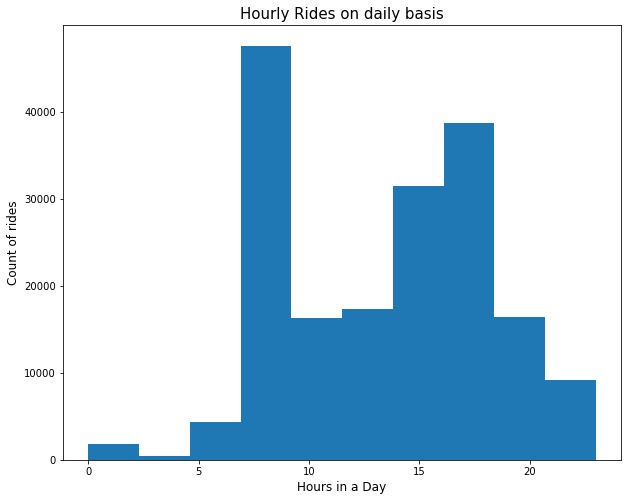

```python
plt.figure(figsize=(10,8))
plt.hist(data = df, x = 'start_hour')
plt.xlabel('Hours in a Day', size=12)
plt.ylabel('Count of rides', size=12)
plt.title('Hourly Rides on daily basis', size=15);
```

## Day vrs Hour

[figure not shown]

```python
plt.figure(figsize = (10,8))
plt.hist2d(data = df, x = 'start_time_day', y = 'start_hour')
plt.xlabel('Start hour', size=12)
plt.ylabel('Day of starting trip', size=12)
plt.title('Day of the Week by Hour of the Day', size=20)
plt.colorbar(label = 'Count of rides');
```

## Distribution of User Type

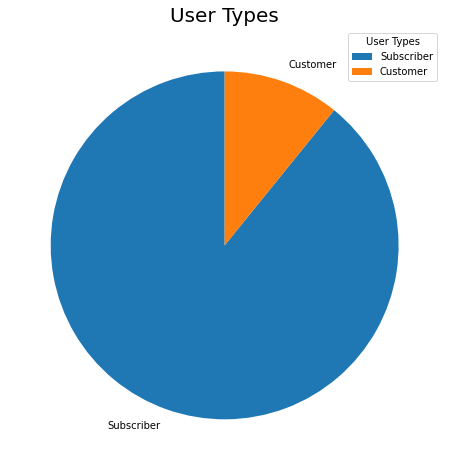

```python
plt.figure(figsize=(8,8))
plt.pie(user_types, labels = ['Subscriber', 'Customer'], startangle = 90);
plt.legend(['Subscriber', 'Customer'], title = 'User Types')
plt.title('User Types', size=20);
```

## User Type vrs Duration(min)

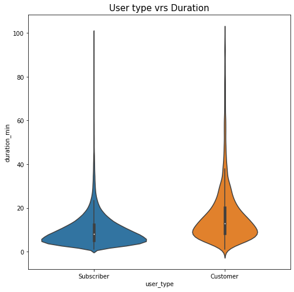

```python
plt.figure(figsize=(8,8))
sb.violinplot(data = df.query('duration_min < 100'), y='duration_min', x='user_type' );
plt.title('User type vrs Duration', size =15);
```

## User Type vrs Day

In general, subscribers use the bike system more than customers in every day of the week.Using a clustered bar chart, helps compared these catrgorical variables sides by side. As depicted in previous visualizations Thursdays has the highest count of rides for both user types.

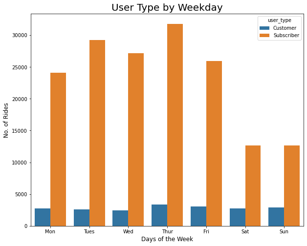

```python
plt.figure(figsize=(10,8))
sb.countplot(data = df, x = 'start_time_day', hue = 'user_type')
plt.title('User Type by Weekday', size = 20)
plt.xticks([0,1,2,3,4,5,6], labels)
plt.xlabel('Days of the Week', size = 12)
plt.ylabel('No. of Rides', size = 12);
```